# My Simple Logistic Regression

## Background

```r
MplsDemo2 <- MplsDemo %>%
    mutate(whiteProb = case_when(
        white > .6 ~ "1",
        white < .6 ~ "0"))

MplsDemofiltered <- select(MplsDemo2, c(neighborhood, population, white, hhIncome, whiteProb))
```

The data used in this analysis was the “MplsDemo” dataset contained in R. This dataset contains information on the Demographics of neighborhoods throughout Minneapolis, Minnesota in 2015. I selected the ‘white’ and ‘hhIncome’ columns to use in the analysis. The white variable represents the proportion of the population in that neighborhood estimated to be white, and the hhIncome variable represents the estimated median household income for that neighborhood.

I first created a Boolean variable, which I called ‘whiteProb’. I decided to create a boundary at white = 0.6, meaning that if the original white variable was greater than 0.6, I would classify that neighborhood as predominantly white and assign it a value of 1. If white was not greater than 0.6, it would be classified as a non-predominantly white neighborhood and was assigned a value of 0. The hhIncome variable was used as a numeric value. The data for this analysis is recorded below, filtered to contain only 5 variables:

```r
datatable(MplsDemofiltered)
```

|  | neighborhood | population | white | hhIncome | whiteProb |
| --- | --- | --- | --- | --- | --- |
| 1 | Cedar Riverside | 8247 | 0.353 | 18892 | 0 |
| 2 | Phillips West | 5184 | 0.199 | 18404 | 0 |
| 3 | Downtown West | 7141 | 0.561 | 67086 | 0 |
| 4 | Downtown East | 1674 | 0.543 | 70669 | 0 |
| 5 | Shingle Creek | 3249 | 0.407 | 59414 | 0 |
| 6 | Ventura Village | 6150 | 0.214 | 17469 | 0 |
| 7 | Sumner - Glenwood | 1676 | 0.087 | 18854 | 0 |
| 8 | Lind - Bohanon | 5420 | 0.417 | 43438 | 0 |
| 9 | Victory | 4525 | 0.622 | 57148 | 1 |
| 10 | Webber - Camden | 5109 | 0.394 | 37030 | 0 |

[output cut: 74 more lines]

## Hypothesis

The following logistic regression model will be used:
$$P(Y_i=1|x_i)=\frac{e^{\beta_0+\beta_1x_i}}{1+e^{\beta_0+\beta_1x_i}}=\pi_i$$

where for a given observation $i$,

$Y_i=1$ denotes at least one neighborhood being predominantly white for a given income,

$Y_i=0$ denotes no neighborhoods being predominantly white, and

$x_i$ represents the estimated median household income.

It is important to recognize that if $\beta_1=0$, then $x_i$ provides no insight to the probability of a neighborhood being predominantly white. We thus will have the hypotheses:

$$H_0: \beta_1 = 0$$
$$H_a: \beta_1 \neq 0$$

## Analysis

```r
Mpls.glm <- glm(formula = (whiteProb == "1") ~ hhIncome, data = MplsDemofiltered, family = binomial)

summary(Mpls.glm) %>%
  pander()
```

|  | Estimate | Std. Error | z value | Pr(>\|z\|) |
| --- | --- | --- | --- | --- |
| **(Intercept)** | -3.191 | 0.8882 | -3.592 | 0.0003279 |
| **hhIncome** | 7.079e-05 | 1.694e-05 | 4.179 | 2.922e-05 |

(Dispersion parameter for binomial family taken to be 1 )

| Null deviance: | 108.27 on 83 degrees of freedom |
| --- | --- |
| Residual deviance: | 76.99 on 82 degrees of freedom |

This table shows us the value of $\beta_0$ and $\beta_1$. The values of $\beta_0$ and $\beta_1$ will be discussed later in the analysis, but we can already see that both of these values are significant.

With these results, we can fill in our original logistic regression model:

$$P(Y_i=1|x_i)=\frac{e^{-3.191+0.00007079x_i}}{1+e^{-3.191+0.00007079x_i}}=\pi_i$$

Looking at this model, we can see that our $b_0=-3.191$, which is the estimate for $\beta_0$. $\beta_1$ is estimated by $b_1=0.00007079$. We can now create a graphical summary of our logistic regression model:

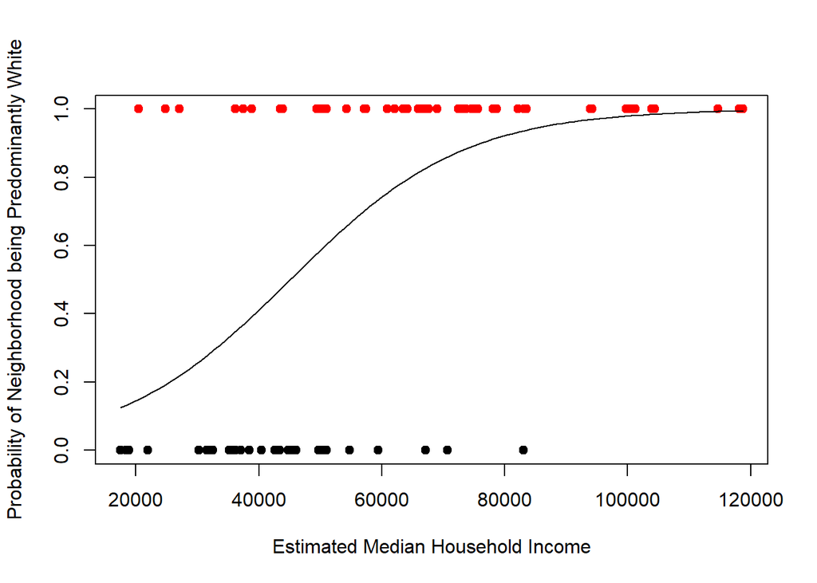

```r
plot(formula = (whiteProb == "1") ~ hhIncome, data = MplsDemofiltered, col = as.factor(whiteProb == "1"), pch = 19, xlab = "Estimated Median Household Income", ylab = "Probability of Neighborhood being Predominantly White")

curve(exp(-3.191+.00007079*x)/(1+exp(-3.191+.00007079*x)), add = TRUE)
```

### Diagnosis of the Model

To check if a logistic regression model was appropriate for the data, we will run the following Hosmer and Lemeshow goodness of fit test, given there are few repeated x-values (2):

```r
hoslem.test(Mpls.glm$y, Mpls.glm$fitted, g=10) %>%
  pander()
```

Hosmer and Lemeshow goodness of fit (GOF) test: `Mpls.glm$y, Mpls.glm$fitted`

| Test statistic | df | P value |
| --- | --- | --- |
| 6.388 | 8 | 0.6039 |

These results ($p=0.6039$) indicate that using a logistic regression model for this data is appropriate, given that our null hypothesis for this test is that it is appropriate.

## Conclusion

Now that we have established it was appropriate to run this test, we can conclude that we reject the null hypothesis based on the results from our logistic regression test: $p=.00002922$. Thus, $\beta_1 \neq 0$. We can further use the results from our test to make other conclusions regarding the probability of a neighborhood being predominantly white.

Using our $b_1$, we can say that for every 1 dollar increase in estimated median household income, the odds that that neighborhood is predominantly white increase by ${e^.00007079}=1.000071$, or $0.0071$%. We pulled this value of $0.00007079$ from our test, which was the value of $b_1$. We also do not interpret the results for our y-intercept, because it is not of much value or interest to examine a median household income of 0.